# The Ultimate Go Study Guide

# 데이터 구조(Data Structures)

## 배열(Array)

### CPU 캐시(CPU Cache)

코어들은 메인 메모리로 바로 접근하지 않고 로컬 캐시로 접근한다. 캐시에는 데이터와 명령어가 저장되어 있다.

캐시 속도는 L1, L2, L3, 메인 메모리 순으로 빠르다. Scott Meyers에 따르면 “만약 퍼포먼스가 중요하다면 모두 캐시 메모리로 접근해야 한다”고 한다. 메인 메모리 접근은 굉장히 느리다. 사실상 접근이 힘들다고 보면 된다.

그래서 캐시 미스(cache miss)가 발생하지 않거나 잠재적인 문제로부터 최소화하는 캐싱 시스템(caching system)은 어떻게 작성해야 할까?

프로세서(Processor)는 프리페처(Prefetcher)를 가지고 있다. 프리페처는 어떤 데이터가 필요할지 예상한다. 데이터 단위(granularity)는 사용하는 기계에 따라 다르다. 대체로 프로그래밍 모델은 바이트를 사용한다. 한 번에 바이트를 읽고 쓸 수 있다. 그러나, 캐싱 시스템의 관점에서 보면 데이터 단위는 1바이트가 아니다. 캐싱 시스템의 관점에서 데이터의 단위는 64바이트고 이걸 캐시 라인(cache line)이라고 부른다. 모든 메모리는 64바이트의 캐시 라인으로 구성되어 있다. 캐싱 메커니즘(caching mechanism)은 복잡하지만 프리페처는 모든 지연 시간을 없애려 한다. 프리페처가 예측 가능한 데이터 접근 패턴을 파악 할 수 있어야 한다. 즉, 예측 가능한 데이터 접근 패턴을 생성하는 코드를 작성해야 한다.

쉬운 방법의 하나는 메모리의 연속 할당을 만들고 이것을 순회하는 것이다. 배열(Array) 데이터 구조는 연속 할당과 순회를 할 수 있게 해준다. 하드웨어 관점에서 배열은 가장 중요한 데이터 구조이며 Go 관점에서 슬라이스(slice)가 그러하다. C++의 vector와 마찬가지로 슬라이스는 배열 기반 자료구조이다. 사이즈가 어떻든 배열을 할당하면, 모든 원소는 각각 다른 원소로부터 같은 거리를 갖게 된다. 배열을 순회하는 건 캐시 라인을 한줄 한줄 순회하는 것과 같다. 프리페처는 접근 패턴을 고르고 모든 지연 시간을 숨긴다.

예를 들어, 큰 nxn 행렬이 있다고 하자. 연결 리스트 순회(LinkedList Traverse), 열 순회(Column Traverse), 행 순회(Row Traverse)를 했을 때 각 순회의 성능을 측정해보자. 당연하게도 행 순회가 가장 높은 성능을 가진다. 행 순회는 행렬의 캐시 라인을 순회하면서 예측 가능한 접근 패턴을 만든다. 이와 달리 열 순회는 캐시 라인을 순회하지 않는다. 메모리 임의 접근 패턴을 가지고 있다. 이게 성능이 제일 느린 이유다. 연결 리스트 순회의 성능이 왜 중간인지 설명하지 않았다. 단순히 열 순회만큼 성능이 안 좋을 거라고 생각해 볼 수 있다. 자세한 이해를 위해 또 다른 캐시인 TLB - 변환 색인 버퍼(Translation Lookaside Buffer)를 알아보자. 변환 색인 버퍼는 물리적 메모리에 있는 운영 체제의 페이지(page)와 오프셋(offset)을 유지한다.

### 변환 색인 버퍼(Translation Lookaside Buffer)

캐싱 시스템은 하드웨어로 한 번에 64바이트씩 데이터를 옮긴다. 데이터 단위는 기계 별로 다르듯이, 운영 체제는 4k(운영 체제의 기존 페이지 크기) 바이트씩 페이징 함으로써 메모리를 관리한다.

관리되는 모든 페이지는 가상 메모리 주소(소프트웨어는 가상 주소를 물리적 메모리를 사용하고 공유하는 샌드박스에서 실행한다)를 갖게 되는데, 올바른 페이지에 매핑되고 물리적 메모리로 오프셋 하기 위해 사용된다.

변환 색인 버퍼의 미스는 캐시 미스보다 나쁠 수 있다. 연결 리스트 순회가 중간 성능인 이유는 다수의 노드가 같은 페이지에 있기 때문이다. 캐시 라인은 예측 가능한 거리를 요구하지 않기 때문에 캐시 미스가 발생 할 수 있지만, 많은 변환 색인 버퍼의 미스는 발생하지 않을 수 있다. 열 순회에서는 캐시 미스뿐만 아니라 엑세스할 때마다 변환 색인 버퍼의 캐시 미스가 발생 할 수 있다.

즉, 데이터 지향 설계가 중요하다. 효율적인 알고리즘을 작성하는 것에 그치지 않고, 어떻게 데이터에 접근하는 것이 알고리즘보다 성능에 좋은 영향을 미칠지 고려해야 한다.

### 선언과 초기화(Declare and initialize)

문자열이 원소이고 길이가 5인 배열을 선언하고, 제로 값(zero value)으로 초기화 해보자. 다시 한 번 더 말하지만, 문자열은 포인터와 길이를 표현하는 두 워드(word)로 이루어진 데이터 구조다. 이 배열을 제로 값(zero value)으로 설정하면, 배열속의 모든 문자열도 제로 값(zero value)이 된다. 각각의 문자열의 첫 번째 워드는 nil을 가리키고 두 번째 워드는 0이 된다.

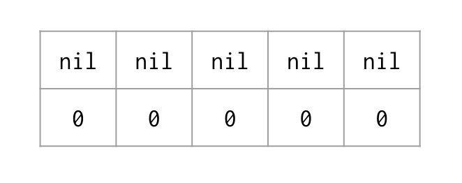

22-1

```go
var strings [5]string
```

인덱스 0의 문자열은 이제 바이트들(문자열을 구성하는 문자들)을 실제로 저장하고 있는 배열에 대한 포인터와 길이 정보 5를 가지게 된다.

### 비용이 얼마나 드는가?(What is the cost?)

```go
strings[0] = "Apple"
```

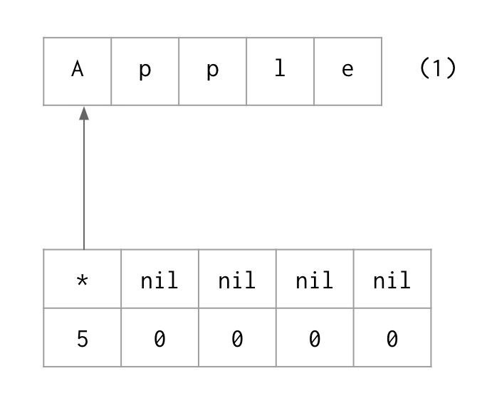

22-2

슬라이스의 남은 부분에도 값을 할당한다.

```go
strings[1] = "Orange"
strings[2] = "Banana"
strings[3] = "Grape"
strings[4] = "Plum"
```

### 문자열 배열 반복(Iterate over the array of strings)

**Println 함수에는 무엇을 전달하는가**

```go
fmt.Printf("\n=> Iterate over array\n")
for i, fruit := range strings {
    fmt.Println(i, fruit)
}
```

```
=> Iterate over array
0 Apple
1 Orange
2 Banana
3 Grape
4 Plum
```

4개의 정수를 가지는 배열을 선언하고 리터럴 표기법(literal syntax)으로 특정 값으로 초기화 한다.

```go
numbers := [4]int{10, 20, 30, 40}
```

전통적인 방법으로 배열을 반복한다.

```go
fmt.Printf("\n=> Iterate over array using traditional style\n")

for i := 0;i < len(numbers);i++ {
    fmt.Println(i, numbers[i])
}
```

```
=> Iterate over array using traditional style
0 10
1 20
2 30
3 40
```

### 다른 타입의 배열들(Different type arrays)

제로 값으로 초기화 된 길이가 5인 정수 형 배열을 선언하자.

```go
var five [5]int
```

특정 값으로 초기화 된 길이가 4인 정수 형 배열을 선언하자.

```go
four := [4]int{10, 20, 30, 40}
```

```go
fmt.Printf("\n=> Different type arrays\n")
fmt.Println(five)
fmt.Println(four)
```

```
=> Different type arrays
[0 0 0 0 0]
[10 20 30 40]
```

`five = four`와 같이 변수 four를 변수 five에 할당하려고 할 때, 컴파일러는 `"cannot use four (type [4]int) as type [5]int in assignment"`라는 메세지를 출력한다. 타입(길이와 표현)이 다르기 때문에 할당 할 수 없다. 배열의 크기는 타입명에 표시 된다: `[4]int` vs `[5]int`. 이것은 포인터의 표현과 같은 맥락이다. `*int`의 *은 연산자가 아니고 타입명의 일부이다. 당연하게도 모든 배열은 컴파일 타임(compile time) 때 정해진 크기를 갖게 된다.

### 연속 메모리 할당(Contiguous memory allocations)

특정 값들로 초기화 된 길이가 6인 문자열 배열을 선언하자.

```go
six := [6]string{"Annie", "Betty", "Charley", "Doug", "Edward", "Hoanh"}
```

이 배열을 반복하면서 각 원소의 값과 주소를 출력하자. `Printf`의 결과를 보면, 이 배열은 연속 된 메모리 블록으로 이루어진 것을 알 수 있다. 문자열은 두 워드로 되어 있고, 컴퓨터 아키텍처에 따라 x 바이트를 가지게 된다. 연속 된 두 `IndexAddr`의 거리는 정확히 x 바이트이다. 변수 `v`는 스택에 있고 매번 같은 주소를 가진다.

```go
fmt.Printf("\n=> Contiguous memory allocations\n")
for i, v := range six {
    fmt.Printf("Value[%s]\tAddress[%p] IndexAddr[%p]\n", v, &v, &six[i])
}
```

```
=> Contiguous memory allocations
Value[Annie] Address[0xc000010250] IndexAddr[0xc000052180]
Value[Betty] Address[0xc000010250] IndexAddr[0xc000052190]
Value[Charley] Address[0xc000010250] IndexAddr[0xc0000521a0]
Value[Doug] Address[0xc000010250] IndexAddr[0xc0000521b0]
Value[Edward] Address[0xc000010250] IndexAddr[0xc0000521c0]
Value[Hoanh] Address[0xc000010250] IndexAddr[0xc0000521d0]
```

## 슬라이스 (Slice)

### 선언과 초기화 (Declare and initialize)

5개의 요소를 갖는 `슬라이스(slice)`를 생성해보자. `make` 함수는 `슬라이스(slice)`와 `맵(map)` 그리고 `채널(channel)` 타입에서 사용하는, 특별한 내장 함수이다. make 함수를 사용하여 5개의 문자열 배열을 갖는 슬라이스를 생성하면, 3개의 워드(word) 데이터 구조가 만들어진다. 첫 번째 워드는 배열을 위치를 가리키고 두 번째 워드는 길이를, 세 번째 워드는 용량을 나타낸다.

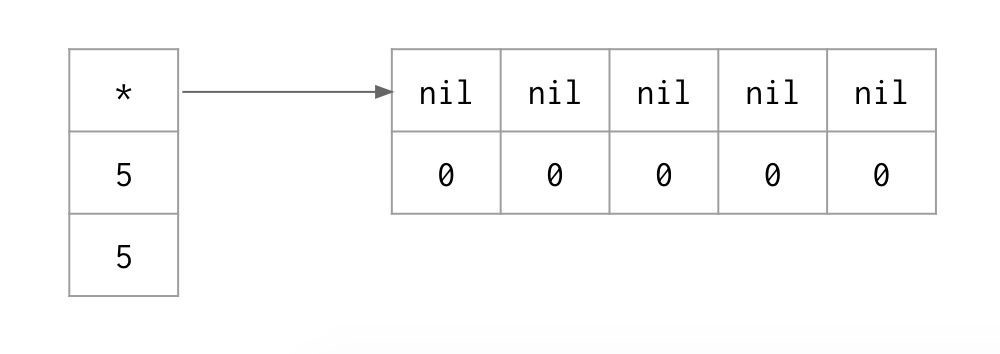

25

### 길이와 용량 (Length vs Capacity)

`길이(Length)`는, 포인터의 위치에서부터 접근해서 읽고 쓸 수 있는 요소의 수를 의미하며, `용량(Capacity)`은 포인터의 위치에서부터 배열에 존재할 수 있는 요소의 총량을 뜻한다.

문법적 설탕(syntactic sugar)을 사용하기에, 슬라이스는 언뜻 배열처럼 보인다. 비용도 배열과 동일하게 발생한다. 하지만, 한 가지 다른 점은 make 함수의 `[]string`의 대괄호 안에 값이 없다는 것이다. 이것으로 배열과 슬라이스를 구분할 수 있다.

```go
slice1 := make([]string, 5)
slice1[0] = "Apple"
slice1[1] = "Orange"
slice1[2] = "Banana"
slice1[3] = "Grape"
slice1[4] = "Plum"
```

슬라이스의 길이를 넘는 인덱스에는 접근할 수 없다.

```
Error: panic: runtime error: index out of range slice1[5] = "Runtime error"
```

슬라이스의 주소가 아닌 값을 전달한다. 따라서, `Println`함수는 슬라이스의 복사본을 갖게 된다.

```go
fmt.Printf("\n=> Printing a slice\n")
fmt.Println(slice1)
```

```
=> Printing a slice
[Apple Orange Banana Grape Plum]
```

### 참조 타입 (Reference type)

5개의 요소를 갖고 용량이 8개인 슬라이스를 만들기 위해 *make* 키워드를 이용할 수 있으며, 이를 통해 초기화 시점에 직접 용량을 정할 수 있다.

결국 우리는, 차례대로 8개의 요소를 갖는 배열을 가르키는 포인터와 길이는 5, 용량은 8을 갖는 3개의 워드(word)형 자료 구조를 갖게된다. 이는 첫 5개의 요소에 대해 읽고 쓸 수 있으며, 필요시 이용 가능한 3개의 용량을 갖는 것을 뜻한다.

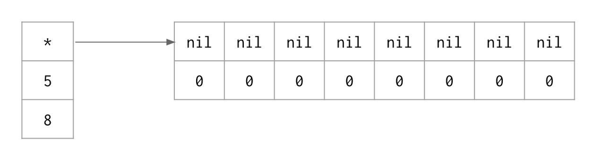

27

```go
slice2 := make([]string, 5, 8)
slice2[0] = "Apple"
slice2[1] = "Orange"
slice2[2] = "Banana"
slice2[3] = "Grape"
slice2[4] = "Plum"
```

```go
fmt.Printf("\n=> Length vs Capacity\n")
inspectSlice(slice2)
```

```go
// inspectSlice는 리뷰를 위해 슬라이스 헤더를 보여주는 함수이다.
// 파라미터 : 다시 말하지만, []string의 대괄호 속에 값이 없으므로 슬라이스를 사용함을 알 수 있다.
// 배열에서 했던 것과 마찬가지로, 슬라이스를 순회한다.
// `len`이 슬라이스의 길이를 알려주며, `cap`은 슬라이스의 용량을 알려준다.
// 결과를 보면, 예상대로 슬라이스의 주소 값들이 정렬되어 표시되는 것을 볼 수 있다.
func inspectSlice(slice []string) {
    fmt.Printf("Length[%d] Capacity[%d]\n", len(slice), cap(slice))
    for i := range slice {
        fmt.Printf("[%d] %p %s\n", i, &slice[i], slice[i])
    }
}
```

[output not shown]

### 추가에 관한 생각: 슬라이스를 동적 자료구조로 만들기. (Idea of appending: making slice a dynamic data structure)

문자열로 구성될 nil 슬라이스를 선언하고 그 값을 제로 값(zero value)으로 설정한다. 이 때, 첫 번째 워드(word)는 nil을 가르키는 포인터로, 두 번째와 세 번째 값은 0을 나타내는 3개의 워드(word) 자료구조를 갖는다.

```go
var data []string
```

만약, `data := string{}`을 하게되면, 이 둘은 서로 같을까?

그렇지 않다. 왜냐하면 이 경우, 데이터는 값이 제로 값(zero value)으로 설정되지 않기 때문이다. 빈 리터럴로 생성되는 모든 타입이 제로 값(zero value)을 반환하지는 않기 때문에, 제로 값(zero value)을 위해 `var`을 사용하는 이유기도하다. 위의 경우에, 반환 되는 슬라이스는 nil 슬라이스가 아닌 포인터를 갖고 있는 빈 슬라이스가 된다. nil 슬라이스와 빈 슬라이스 간에는 각기 다른 의미가 있는데, 제로 값(zero value)으로 설정된 참조 타입은 nil로 여길 수 있다는 점이다. marshal 함수에 nil 슬라이스를 넘긴다면 null을 반환하고, 빈 슬라이스를 넘긴다면 빈 JSON을 반환하게 된다. 그렇다면 이 때 포인터는 어떤 것을 가르키게 될까? 바로, 나중에 살펴볼 빈 구조체를 가르킨다.

슬라이스의 용량을 가져오자.

```go
    lastCap := cap(data)
```

슬라이스에 약 10만개의 문자열을 덧붙인다.

```go
    for record := 1;record <= 102400;record++ {
```

내장 함수인 `append`를 사용해서 슬라이스를 덧붙일 수 있다. 이 함수를 통해 슬라이스에 값을 추가할 수 있으며 자료 구조를 동적으로 만들 수 있으면서도, 기계적 동정심(mechanical sympathy)을 통해 예측 가능한 접근 패턴을 제공함으로써 여전히 인접한 메모리 블럭을 이용할 수 있게 된다. `append` 함수는 값 개념(value semantic)으로 동작한다. 슬라이스 자체를 공유하는 것이 아니라, 슬라이스에 값을 덧붙이고 그 복사본을 반환하는 식이다. 따라서 슬라이스는 힙 메모리가 아닌 스택에 위치하게 된다.

```go
    data = append(data, fmt.Sprintf("Rec: %d", record))
```

```go
    if lastCap != cap(data) {
```

변화율을 계산한다.

```go
    capChg := float64(cap(data)-lastCap) / float64(lastCap) * 100
```

`lastCap`에 새 용량을 저장한다.

```go
    lastCap = cap(data)
```

결과를 표시한다.

```go
    fmt.Printf("Addr[%p]\tIndex[%d]\t\tCap[%d - %2.f%%]\n", &data[0], record, cap(data), capChg)
```

```
=> Idea of appending
Addr[0xc0000102a0] Index[1] Cap[1 - +Inf%]
Addr[0xc00000c0c0] Index[2] Cap[2 - 100%]
Addr[0xc000016080] Index[3] Cap[4 - 100%]
Addr[0xc00007e080] Index[5] Cap[8 - 100%]
Addr[0xc000100000] Index[9] Cap[16 - 100%]
Addr[0xc000102000] Index[17] Cap[32 - 100%]
Addr[0xc00007a400] Index[33] Cap[64 - 100%]
Addr[0xc000104000] Index[65] Cap[128 - 100%]
Addr[0xc000073000] Index[129] Cap[256 - 100%]
Addr[0xc000106000] Index[257] Cap[512 - 100%]
Addr[0xc00010a000] Index[513] Cap[1024 - 100%]
Addr[0xc000110000] Index[1025] Cap[1280 - 25%]
Addr[0xc00011a000] Index[1281] Cap[1704 - 33%]
Addr[0xc000132000] Index[1705] Cap[2560 - 50%]
Addr[0xc000140000] Index[2561] Cap[3584 - 40%]
Addr[0xc000154000] Index[3585] Cap[4608 - 29%]
Addr[0xc000180000] Index[4609] Cap[6144 - 33%]
Addr[0xc000198000] Index[6145] Cap[7680 - 25%]
Addr[0xc0001b6000] Index[7681] Cap[9728 - 27%]
Addr[0xc000200000] Index[9729] Cap[12288 - 26%]
Addr[0xc000230000] Index[12289] Cap[15360 - 25%]
Addr[0xc000280000] Index[15361] Cap[19456 - 27%]
Addr[0xc000300000] Index[19457] Cap[24576 - 26%]
Addr[0xc000360000] Index[24577] Cap[30720 - 25%]
Addr[0xc000400000] Index[30721] Cap[38400 - 25%]
Addr[0xc000300000] Index[38401] Cap[48128 - 25%]
Addr[0xc000600000] Index[48129] Cap[60416 - 26%]
Addr[0xc0006ec000] Index[60417] Cap[75776 - 25%]
Addr[0xc000814000] Index[75777] Cap[94720 - 25%]
Addr[0xc000600000] Index[94721] Cap[118784 - 25%]
```

### 슬라이스의 슬라이스

`slice2`의 인덱스 2, 인덱스 3의 값을 갖는 `slice3`을 생성하자. `slice3`의 길이는 2이고 용량은 6이다.

매개변수는 `[시작 인덱스:(시작 인덱스 + 길이)]` 형태이다.

결과를 통해 두 슬라이스는 같은 배열을 공유하고 있는 것을 알 수 있다. 슬라이스의 헤더는 값의 개념으로 사용 될 때 스택에 존재한다. 오직 공유되는 배열만이 힙에 위치한다.

```go
slice3 := slice2[2:4]
```

```go
fmt.Printf("\n=> Slice of slice (before)\n")
inspectSlice(slice2)
inspectSlice(slice3)
```

```
=> Slice of slice (before)
Length[5] Capacity[8]
[0] 0xc00007e000 Apple
[1] 0xc00007e010 Orange
[2] 0xc00007e020 Banana
[3] 0xc00007e030 Grape
[4] 0xc00007e040 Plum
Length[2] Capacity[6]
[0] 0xc00007e020 Banana
[1] 0xc00007e030 Grape
```

```go
slice3[0] = "CHANGED"
```

두 슬라이스 모두 변한다. 생성되어 있는 슬라이스를 변경한다는 것을 잊지 말아야 한다. 어디서 이 슬라이스를 사용하는지, 또 배열을 공유하고 있는지를 주의깊게 살펴야 한다.

```go
fmt.Printf("\n=> Slice of slice (after)\n")
inspectSlice(slice2)
inspectSlice(slice3)
```

```
=> Slice of slice (after)
Length[5] Capacity[8]
[0] 0xc00007e000 Apple
[1] 0xc00007e010 Orange
[2] 0xc00007e020 CHANGED
[3] 0xc00007e030 Grape
[4] 0xc00007e040 Plum
Length[2] Capacity[6]
[0] 0xc00007e020 CHANGED
[1] 0xc00007e030 Grape
```

`slice3 := append(slice3, "CHANGED")`는 어떨까? 슬라이스의 길이와 용량이 다르면, `append`를 사용 할 때 비슷한 문제가 발생한다. `slice3`의 0번째 인덱스 값을 변경하는 대신에, `append`를 호출 해보자. `slice3`의 길이는 2이고 용량은 6이라서 수정을 위한 여유 공간을 가지고 있다. `slice2`의 4번째 인덱스와 같은 주소 값을 가지는 `slice3`의 3번째 인덱스의 원소부터 변경 된다. 이런 상황은 굉장히 위험하다. 그러면 슬라이스의 길이와 용량이 서로 같으면 어떨까? 슬라이싱 구문(slicing syntax)의 또 다른 매개변수를 추가하여, `slice3`의 용량을 6 대신 2로 만들어보자: `slice3 := slice2[2:4:4]`

길이와 용량이 같은 슬라이스에 대해 `append`가 호출 되면, `slice2`의 4번째 원소를 가지고 오지 않는다. 이것은 분리되어 있다. `slice3`는 길이가 2이고 용량이 2이면서 여전히 `slice2`와 같은 배열을 공유하고 있다. `append`가 호출 되면, 길이와 용량이 달라지게 된다. 주소 또한 달라지게 된다. 길이는 3인 새로운 슬라이스가 된다. 새로운 슬라이스 소유의 배열을 갖게 되고 더 이상 원본 슬라이스의 영향을 받지 않는다.

### 슬라이스 복사

복사는 문자열과 슬라이스 타입에서만 동작 한다. 원본의 요소들을 담을 수 있을 만큼의 크기로 새로운 슬라이스를 만들고 내장 함수인 `copy`를 사용해서 값을 복사한다.

```go
slice4 := make([]string, len(slice2))
copy(slice4, slice2)

fmt.Printf("\n=> Copy a slice\n")
inspectSlice(slice4)
```

```
=> Copy a slice
Length[5] Capacity[5]
[0] 0xc00005c050 Apple
[1] 0xc00005c060 Orange
[2] 0xc00005c070 CHANGED
[3] 0xc00005c080 Grape
[4] 0xc00005c090 Plum
```

### 슬라이스와 참조

길이가 7인 정수형 슬라이스를 선언하자.

```go
x := make([]int, 7)
```

임의의 값을 넣어준다.

```go
for i := 0; i < 7; i++ {
    x[i] = i * 100
}
```

슬라이스의 두 번째 원소의 포인터를 변수에 할당한다.

```go
twohundred := &x[1]
```

슬라이스에 새로운 값을 추가해보자. 이 코드는 위험 하다. x 슬라이스는 길이가 7이고 용량 7이다. 길이와 용량이 같기 때문에 용량이 두 배로 늘어나고 값들이 복사된다. 이제 x 슬라이스는 길이가 8이고 용량이 14이며 다른 메모리 블록을 가르킨다.

```go
x = append(x, 800)
```

슬라이스의 두 번째 원소의 값을 변경 할 때, `twohundred`는 변경되지 않는다. 이전의 슬라이스를 가리키기 때문이다. 이 변수를 읽을 때 마다, 잘못된 값을 얻는다.

```go
x[1]++
```

결과를 출력함으로써, 문제를 확인 할 수 있다.

```go
fmt.Printf("\n=> Slice and reference\n")
fmt.Println("twohundred:", *twohundred, "x[1]:", x[1])
```

```
=> Slice and reference
twohundred: 100 x[1]: 101
```

### UTF-8

Go의 모든 것은 UTF-8 문자 집합(chrarcter sets)을 근간으로 한다. 만약 다른 인코딩 구조를 사용한다면 문제가 발생한다.

중국어와 영어로 문자열을 선언하자. 중국 문자는 각각 3 바이트를 사용한다. UTF-8는 바이트, 코드 포인트(code point) 그리고 문자로 3 계층을 이루고 있다. Go 관점에서 문자열은 단지 저장되는 바이트일 뿐이다.

아래 예제에서 첫 번째 3 바이트는 하나의 코드 포인트를 표현한다. 하나의 코드 포인트는 하나의 문자를 표현한다. 1 바이트부터 4 바이트를 가지고 코드 포인트를 표현 할 수 있고(코드 포인트는 32 비트 값이다.) 1 부터 대다수의 코드 포인트는 문자를 표현 할 수 있다. 간단하게, 3 바이트로 1 코드 포인트로 1 문자를 표현한다. 그래서 s 문자열을 3 바이트, 3 바이트, 1 바이트, 1 바이트.. 로 읽는다(앞 부분에 중국 문자가 2개 있고 나머지는 영어이기 때문에)

```go
s := "世界 means world"
```

`UTFMax` 상수 4다. – 인코딩 된 룬당 최대 4 바이트 -> 모든 코드 포인트를 표현하기 위해 필요한 최대 바이트 수는 4 바이트다.[재방문] `Rune`은 자체 타입이다. 이것은 `int32` 타입의 별칭이다. 우리가 사용하는 `byte` 타입은 `uint8`의 별칭이다.

```go
var buf [utf8.UTFMax]byte
```

위의 문자열을 순회 할 때, 바이트에서 바이트, 코드 포인트에서 코드 포인트, 문자에서 문자로 중 어느 방식으로 순회할까? 정답은 코드 포인트에서 코드 포인트이다. 첫 번째 순회에서 i는 0이다. 그 다음 i는 다음 코드 포인트로 이동되기 때문에 3이다. 그 다음은 6이다.

```go
for i, r := range s {
```

룬/코드 포인트의 바이트 수를 출력해보자.

```go
    rl := utf8.RuneLen(r)
```

룬을 표현하는 바이트들의 차이를 계산하자.

```go
    si := i + rl
```

문자열로부터 룬을 버퍼에 복사하자. 모든 코드 포인트를 순회하며 배열 버퍼에 복사하고 화면에 출력하려는 것이다. Go 에서 “배열은 언제든 슬라이스가 될 준비가 되어있다.” 슬라이싱 구문을 사용하여 `buf` 배열을 가리키는 슬라이스 헤더를 만든다. 헤더는 스택에 생성되기에 힙에 할당하지 않는다.

```go
    copy(buf[:], s[i:si])
```

출력해보자.

```go
    fmt.Printf("%2d: %q; codepoint: %#6x; encoded bytes: %#v\n", i, r, r, buf[:rl])
```

```
0: '世'; codepoint: 0x4e16; encoded bytes: []byte{0xe4, 0xb8, 0x96}
3: '界'; codepoint: 0x754c; encoded bytes: []byte{0xe7, 0x95, 0x8c}
6: ' '; codepoint: 0x20; encoded bytes: []byte{0x20}
7: 'm'; codepoint: 0x6d; encoded bytes: []byte{0x6d}
8: 'e'; codepoint: 0x65; encoded bytes: []byte{0x65}
9: 'a'; codepoint: 0x61; encoded bytes: []byte{0x61}
10: 'n'; codepoint: 0x6e; encoded bytes: []byte{0x6e}
11: 's'; codepoint: 0x73; encoded bytes: []byte{0x73}
12: ' '; codepoint: 0x20; encoded bytes: []byte{0x20}
13: 'w'; codepoint: 0x77; encoded bytes: []byte{0x77}
14: 'o'; codepoint: 0x6f; encoded bytes: []byte{0x6f}
15: 'r'; codepoint: 0x72; encoded bytes: []byte{0x72}
16: 'l'; codepoint: 0x6c; encoded bytes: []byte{0x6c}
17: 'd'; codepoint: 0x64; encoded bytes: []byte{0x64}
```

### 맵(Map)

프로그램에서 사용할 `user`를 정의한다.

```go
type user struct {
    name string
    username string
}
```

### 선언과 초기화(Declare and initialize)

`string` 타입을 키로, `user` 타입을 값으로 갖는 맵을 선언하고 만든다.

```go
func main() {
    users1 := make(map[string]user)

    // 맵에 키/값 쌍을 추가한다.
    users1["Roy"] = user{"Rob", "Roy"}
    users1["Ford"] = user{"Henry", "Ford"}
    users1["Mouse"] = user{"Mickey", "Mouse"}
    users1["Jackson"] = user{"Michael", "Jackson"}

    // `map`을 순회한다.
    fmt.Printf("\n=> Iterate over map\n")
    for key, value := range users1 {
            fmt.Println(key, value)
}
```

```
=> Iterate over map
Roy {Rob Roy}
Ford {Henry Ford}
Mouse {Mickey Mouse}
Jackson {Michael Jackson}
```

### 맵 리터럴(Map literals)

초기값을 갖는 맵을 선언하고 초기화한다.

```go
users2 := map[string]user{
    "Roy": {"Rob", "Roy"},
    "Ford": {"Henry", "Ford"},
    "Mouse": {"Mickey", "Mouse"},
    "Jackson": {"Michael", "Jackson"},
}
```

```go
// 맵을 순회한다.
fmt.Printf("\n=> Map literals\n")
for key, value := range users2 {
    fmt.Println(key, value)
}
```

```
=> Map literals
Roy {Rob Roy}
Ford {Henry Ford}
Mouse {Mickey Mouse}
Jackson {Michael Jackson}
```

### 키 삭제(Delete key)

```go
delete(users2, "Roy")
```

### 키 찾기(Find key)

키 `Roy`를 찾아보자. 만약 키 중에 `Roy`가 존재한다면, 그에 해당하는 값을 가져와 할당한다. 그렇지 않다면 `u`는 여전히 `user` 타입의 값을 가지겠지만, 그 값은 제로 값으로 설정된다.

```go
u1, found1 := users2["Roy"]
u2, found2 := users2["Ford"]
```

값과 키의 존재 여부를 나타낸다.

```go
fmt.Printf("\n=> Find key\n")
fmt.Println("Roy", found1, u1)
fmt.Println("Ford", found2, u2)
```

```
=> Find key
Roy false { }
Ford true {Henry Ford}
```

### 맵의 키 제한(Map key restrictions)

```go
type users []user
```

이 구문을 사용하여 `users` 를 새로 정의할 수 있으며, 이는 `users`를 정의하는 두 번째 방법이다. 이처럼 이미 존재하는 타입을 통해, 다른 타입의 타입으로 사용할 수 있다. 이 때 두 타입은 서로 연관성이 없다. 하지만 다음의 코드 `u := make(map[users]int)`와 같이 키로서 사용코자 할 때, 컴파일러는 다음의 오류를 발생시킨다. “맵의 키로써 `users` 타입은 유효하지 않다.”

그 이유는, 키로 어떤 것을 사용하던지 그 값은 반드시 비교가능해야 하기 때문이다. 맵이 키의 해시 값을 만들 수 있는 지 보여주는 일종의 불리언 표현식을 사용해야한다.

# 디커플링

## 메서드(method)

### 값 리시버와 포인터 리시버를 이용한 호출(Value and Pointer Receiver Call)

```go
type user struct {
    name  string
    email string
}
```

`notify`는 값 리시버를 가지는 메서드(method)이다. `u`는 `user`타입으로, Go에서는 함수가 리시버와 함께 선언된다면 이를 메서드라고 한다. 리시버는 파라미터와 비슷하게 보이지만, 이는 자신만의 역할이 있다. 값 리시버를 사용하면, 메서드는 자신을 호출한 변수를 복사하고, 그 복사본을 가지고 동작한다.

```go
func (u user) notify() {
    fmt.Printf("Sending User Email To %s<%s>\n", u.name, u.email)
}
```

`changeEmail`은 포인터 리시버를 가지는 메서드이다: `u`는 `user`의 포인터 타입으로, 포인터 리시버를 이용하면 메서드를 호출한 변수를 공유하면서 바로 접근이 가능하다.

```go
func (u *user) changeEmail(email string) {
    u.email = email
    fmt.Printf("Changed User Email To %s\n", email)
}
```

위의 두 메서드들은 값 리시버와 포인터 리시버의 차이를 이해하기 위해서 같이 사용되었다. 하지만 실제 개발에서는 하나의 리시버를 사용하는 것을 권장한다. 이에 대해서는 나중에 다시 살펴볼 것이다.

**값 리시버와 포인터 리시버를 이용한 호출**

`user` 타입의 변수는 값 리시버와 포인터 리시버를 사용하는 모든 메서드를 호출할 수 있다.

```go
bill := user{"Bill", "bill@email.com"}
bill.notify()
bill.changeEmail("bill@hotmail.com")
```

```
Sending User Email To Bill<bill@email.com>
Changed User Email To bill@hotmail.com
```

`user`의 포인터 타입 변수 역시 값 리시버와 포인터 리시버를 사용하는 모든 메서드를 호출할 수 있다.

```go
hoanh := &user{"Hoanh", "hoanhan@email.com"}
hoanh.notify()
hoanh.changeEmail("hoanhan101@gmail.com")
```

```
Sending User Email To Hoanh<hoanhan@email.com>
Changed User Email To hoanhan101@gmail.com
```

이 예제에서 `hoanh`은 `user` 타입을 가리키는 포인터 변수이다. 하지만 값 리시버로 구현된 `notify`를 호출할 수 있다. `user` 타입의 변수로 메서드를 호출하지만, Go는 내부적으로 이를 `(*hoanh).notify()`로 호출한다. Go는 `hoanh`이 가리키는 값을 찾고, 이 값을 복사하여 `notify`를 값에 의한 호출(value semantic)이 가능하도록 한다. 이와 유사하게 `bill`은 `user` 타입의 변수이지만, 포인터 리시버로 구현된 `changeEmail`을 호출할 수 있다. Go는 `bill`의 주소를 찾고, 내부적으로 `(&bill).changeEmail()`을 호출한다.

두 개의 `user` 타입 원소를 가진 슬라이스를 만들자.

```go
users := []user{
    {"bill", "bill@email.com"},
    {"hoanh", "hoanh@email.com"},
}
```

이 슬라이스에 `for ... range`를 사용하면, 각 원소의 복사본을 만들고, `notify` 호출을 위해 또 다른 복사본을 만들게 된다.

```go
for _, u := range users {
    u.notify()
}
```

[output not shown]

포인터 리시버를 사용하는 `changeEmail`을 `for ... range` 안에서 사용해보자. 이는 복사본의 값을 변경하는 것으로 이렇게 사용하면 안 된다.

```go
for _, u := range users {
    u.changeEmail("it@wontmatter.com")
}
```

```
Changed User Email To it@wontmatter.com
Changed User Email To it@wontmatter.com
```

### 값에 의한 호출과 참조에 의한 호출(Value and Pointer Semantics)

숫자, 문자열, 불과 같은 기본 타입을 사용하는 경우, 값에 의한 호출을 사용하는 것을 권장한다. 만약 정수 또는 불 타입 변수의 주소 값을 사용해야 한다면 주의해야 한다. 상황에 따라, 이 방법이 맞을 수도 있고, 아닐 수도 있기 때문이다. 하지만 일반적으로, 메모리 누수의 위험이 있는 힙 메모리 영역에 이 변수들을 만들 필요는 없다. 그래서 이 타입의 변수들은 stack에 생성하는 것을 더 권장한다. 모든 것에는 예외가 있을 수 있지만, 그 예외를 적용하는 것이 적합하다고 판단하기 전에는 규칙을 따를 필요가 있다.

슬라이스, 맵, 채널, 인터페이스와 같이 참조 타입의 변수들 역시 기본적으로 값에 의한 호출을 사용하는 것을 권장한다. 다만 변수의 주소 값을 파라미터로 받는 `Unmarshal`같은 함수를 사용하기 위한 경우라면, 이 타입들의 주소 값을 사용해야 한다.

아래 예제들은 실제 Go의 표준 라이브러리에서 사용하는 코드들이다. 이들을 공부해보면, 값에 의한 호출과 참조에 의한 호출(pointer semantic) 중 하나를 일관되게 사용하는 것이 얼마나 중요한지 알 수 있다. 따라서 변수의 타입을 정할 때, 다음의 질문에 스스로 답해보자.

- 이 타입은 값에 의한 호출과 참조에 의한 호출 중 어느 것이 더 적합한가?
- 만약 이 변수의 값을 변경해야 한다면, 새로운 값을 가지는 복사본을 만드는 것과, 다른 곳에서도 이 변경된 값을 확인할 수 있게 이 변수의 값을 직접 변경하는 것 중 어느 것이 더 적합한가?

가장 중요한 것은 일관성이다. 처음에 한 결정이 잘못되었다고 판단되면, 그때 이를 변경하면 된다.

```go
package main

import (
    "sync/atomic"
    "syscall"
)
```

**값에 의한 호출**

Go의 `net` 패키지는 `IP`와 `IPMask` 타입을 제공하는데, 이들은 바이트 형 슬라이스이다. 아래의 예제들은 이 참조 타입들을 값에 의한 호출을 통해 사용하는 것을 보여준다.

```go
type IP []byte
type IPMask []byte
```

`Mask`는 `IP` 타입의 값 리시버를 사용하며, `IP` 타입의 값을 반환한다. 이 메서드는 `IP` 타입에 대해서 값에 의한 호출을 사용하는 것이다.

```go
func (ip IP) Mask(mask IPMask) IP {
    if len(mask) == IPv6len && len(ip) == IPv4len && allFF(mask[:12]) {
        mask = mask[12:]
    }
    if len(mask) == IPv4len && len(ip) == IPv6len &&
        bytesEqual(ip[:12], v4InV6Prefix) {
        ip = ip[12:]
    }
    n := len(ip)
    if n != len(mask) {
        return nil
    }
    out := make(IP, n)
    for i := 0; i < n; i++ {
        out[i] = ip[i] & mask[i]
    }
    return out
}
```

`ipEmptyString`은 `IP` 타입의 값을 파라미터로 받고, 문자열 타입의 값을 반환한다. 이 함수는 `IP` 타입에 대해서 값에 의한 호출을 사용하는 것이다.

```go
func ipEmptyString(ip IP) string {
    if len(ip) == 0 {
        return ""
    }
    return ip.String()
}
```

**참조에 의한 호출**

`Time` 타입은 값에 의한 호출과 참조에 의한 호출 중 어떤 것을 사용해야 할까? 만약 `Time` 타입 변수의 값을 변경해야 한다면, 이 값을 직접 변경해야 할까? 아니면 복사본을 만들어서 값을 변경하는 것이 좋을까?

```go
type Time struct {
    sec  int64
    nsec int32
    loc  *Location
}
```

타입에 대해 어떤 호출을 사용할지를 결정하는 가장 좋은 방법은 타입의 생성 함수를 확인하는 것이다. 이 생성 함수는 어떤 호출을 사용해야 하는지 알려준다. 이 예제에서, `Now` 함수는 `Time` 타입의 값을 반환한다. `Time` 타입의 값은 한번 복사가 이루어지고, 이 복사된 값은 이 함수를 호출한 곳으로 반환된다. 즉, 이 `Time` 타입의 값은 스택(stack)에 저장된다. 따라서 값에 의한 호출을 사용하는 것이 좋다.

```go
func Now() Time {
    sec, nsec := now()
    return Time{sec + unixToInternal, nsec, Local}
}
```

`Add`는 기존의 `Time` 타입의 값과는 다른 값을 얻기 위한 메서드다. 만약 값을 변경할 때는 무조건 참조에 의한 호출을 사용하고, 그렇지 않을 때는 값에 의한 호출을 사용해야 한다면 이 `Add`의 구현은 잘못되었다고 생각할 수 있다. 하지만, 타입은 어떤 호출을 사용할지를 책임지는 것이지, 메서드의 구현을 책임지는 것은 아니다. 메서드는 반드시 선택된 호출을 따라야 하고, 그래서 `Add`의 구현은 틀리지 않았다.

`Add`는 값 리시버를 사용하고, `Time` 타입의 값을 반환한다. 즉, 이 메서드는 실제로 `Time` 타입 변수의 복사본을 변경하며, 완전히 새로운 값을 반환하는 것이다.

```go
func (t Time) Add(d Duration) Time {
    t.sec += int64(d / 1e9)
    nsec := int32(t.nsec) + int32(d%1e9)
    if nsec >= 1e9 {
        t.sec++
        nsec -= 1e9
    } else if nsec <  0  {
        t.sec--
        nsec += 1e9
    }
    t.nsec = nsec
    return t
}
```

`div`는 `Time` 타입의 파라미터를 받고, 기본 타입의 값들을 반환한다. 이 함수는 `Time` 타입에 대해 값에 의한 호출을 사용하는 것이다.

```go
func div(t Time, d Duration) (qmod2 int, r Duration) {}
```

`Time` 타입에 대한 참조에 의한 호출은, 오직 주어진 데이터를 `Time` 타입으로 변환해 이 메서드를 호출한 변수를 수정할 할 때만 사용한다:

```go
func (t *Time) UnmarshalBinary(data []byte) error {}
func (t *Time) GobDecode(data []byte) error {}
func (t *Time) UnmarshalJSON(data []byte) error {}
func (t *Time) UnmarshalText(data []byte) error {}
```

대부분의 구조체(struct) 타입들은 값에 의한 호출을 잘 사용하지 않는다. 이는 다른 코드에서 함께 공유하거나 또는 공유하면 좋은 데이터들이기 때문이다. `User` 타입이 대표적인 예이다. `User` 타입의 변수를 복사하는 것은 가능은 하지만, 이는 실제로 좋은 구현이 아니다.

다른 예제를 살펴보자:

앞서 이야기했듯이, 생성 함수는 어떤 호출을 사용해야 하는지를 알려준다. `Open` 함수는 `File` 타입 데이터의 주소 값, 즉 `File` 타입 포인터를 반환한다. 이는 `File` 타입에 대해, 참조에 의한 호출을 사용해서 이 `File` 타입의 값을 공유할 수 있다는 것을 뜻한다.

```go
func Open(name string) (file *File, err error) {
    return OpenFile(name, O_RDONLY, 0)
}
```

`Chdir`은 `File` 타입의 포인터 리시버를 사용한다. 즉, 이 메서드는 `File` 타입에 대해 참조에 의한 호출을 사용하는 것이다.

```go
func (f *File) Chdir() error {
    if f == nil {
        return ErrInvalid
    }
    if e := syscall.Fchdir(f.fd); e != nil {
        return &PathError{"chdir", f.name, e}
    }
    return nil
}
```

`epipecheck`는 `File` 타입의 포인터를 파라미터로 받는다. 따라서 이 함수는 `File` 타입에 대해 참조에 의한 호출을 사용하는 것이다.

```go
func epipecheck(file *File, e error) {
    if e == syscall.EPIPE {
        if atomic.AddInt32(&file.nepipe, 1) >= 10 {
            sigpipe()
        }
    } else {
        atomic.StoreInt32(&file.nepipe, 0)
    }
}
```

### 메서드는 단지 함수일 뿐이다

메서드는 특수한 기능이 아니라 문법적인 필요에 의해 만들어진 것이다. 메서드는 데이터와 관련된 일부 기능을 외부에서 사용할 수 있는 것처럼 믿게 만든다. 객체지향 프로그래밍에서도 이러한 설계와 기능을 권장한다. 하지만 Go가 객체지향 프로그래밍를 추구하는 것은 아니다. 다만 데이터와 동작이 필요하기 때문에 이들이 있는 것이다.[재방문]

어떤 때는 데이터가 일부 기능을 노출할 수 있지만 특정 목적을 위해 API를 설계하는 것은 아니다. 메서드는 함수와 거의 동일하다.[재방문]

```go
type data struct {
    name string
    age  int
}
```

`displayName`은 `data`타입 `d` 변수의 `name`을 포함한 문자열을 출력한다. 이 메서드는 `data`를 값 리시버로 사용한다.

```go
func (d data) displayName() {
    fmt.Println("My Name Is", d.name)
}
```

`setAge`는 `data`타입 `d`의 `age`를 수정하고, 이 값을 `name`과 함께 출력한다. 이 메서드는 `data`를 포인터 리시버로 사용한다.

```go
func (d *data) setAge(age int) {
    d.age = age
    fmt.Println(d.name, "Is Age", d.age)
}
```

**메서드는 단지 함수일 뿐이다**

`data` 타입의 변수를 선언해보자.

```go
d := data{
    name: "Hoanh",
}
fmt.Println("Proper Calls to Methods:")
```

다음과 같이 메서드를 호출할 수 있다.

```go
d.displayName()
d.setAge(21)

fmt.Println("\nWhat the Compiler is Doing:")
```

다음 예제를 통해 Go가 내부적으로 어떻게 동작하는지 알 수 있다. `d.displayName()`을 호출하면, 컴파일러는 `data.displayName`을 먼저 호출해서 `data` 타입의 값 리시버를 사용하는 것을 보여주고, `d`를 첫번째 파라미터로 전달한다. `func (d data) displayName()`을 다시 자세히 보면, 리시버가 정말 파라미터임을 알 수 있다. 즉, 이 리시버는 `displayName`의 첫번째 파라미터이다.

`d.setAge(21)` 역시 이와 비슷하다. Go는 포인터 리시버를 사용하는 함수를 호출하고, `d`를 함수의 파라미터로 넘긴다. 추가로 `d`의 주소 값을 이용하기 위하여 약간의 조정이 필요하다.

```go
data.displayName(d)
(*data).setAge(&d, 21)
```

```
Proper Calls to Methods:
My Name Is Hoanh
Hoanh Is Age 21

What the Compiler is Doing:
My Name Is Hoanh
Hoanh Is Age 21
```

**함수형 변수**

```go
fmt.Println("\nCall Value Receiver Methods with Variable:")
```

함수형 변수를 선언하고, 이 변수에 `d` 변수의 메서드를 설정해보자. 이 메서드, `displayName`,은 값 리시버를 사용하기 때문에, 함수형 변수 `f1`은 `d`의 독립적인 복사본을 가진다. 함수형 변수 `f1`은 참조 타입으로 포인터, 즉 주소 값을 저장한다. `displayName`의 뒤에 `()`을 붙이지 않았으므로, 이 메서드의 반환 값을 저장한 것이 아니다.

```go
f1 := d.displayName
```

이 변수를 이용해서 메서드를 호출해보자.

`f1`은 포인터로, 이는 2개의 워드를 가지는 특별한 자료 구조를 가리킨다. 첫 번째 워드는 실행 대상인 메서드를 가리키는데, 이 예제에서는 `displayName`이다. 이 `displayName`는 값 리시버를 사용하므로 실행하기 위해서는 `data` 타입의 값이 필요하다. 따라서 두 번째 워드는 이 값의 복사본을 가리킨다. `displayName`을 `f1`에 저장을 하면, 자동으로 `d`의 복사본이 만들어진다.

만약 `d`의 멤버 변수인 name의 값을 “Hoanh An”으로 변경하더라도, `f1`에는 이 변경이 적용되지 않는다.

```go
d.name = "Hoanh An"
```

`f1`을 통해서 메서드를 호출해보자. 앞서 이야기했듯이, 결과는 변하지 않았다.

```go
f1()
```

```
Call Value Receiver Methods with Variable:
My Name Is Hoanh
My Name Is Hoanh
```

하지만 `setAge` 메서드를 저장한 `f2`는 `d`의 값이 변하면 그 자신의 결과도 변한다.

```go
fmt.Println("\nCall Pointer Receiver Method with Variable:")
```

함수형 변수를 선언하고, 이 변수에 `d` 변수의 메서드를 설정해보자. 이 메서드, `setAge`는 포인터 리시버를 사용하므로, 이 함수형 변수는 `d`의 주소 값을 가지게 된다.

```go
f2 := d.setAge
d.name = "Hoanh An Dinh"
```

이 함수형 변수를 이용해서 메서드를 호출해보자. `f2`는 역시 포인터이고, 2개의 워드를 가지는 자료 구조를 가리킨다. 첫 번째 워드는 `setAge` 메서드를 가리키지만, 두 번째 워드는 더 이상 복사본이 아니라 원본 `d`를 가리킨다.

```go
f2(21)
```

```
Call Pointer Receiver Method with Variable:
Hoanh An Dinh Is Age 21
```

## 인터페이스

### 값이 없는 타입

`reader`는 데이터를 읽는 동작을 정의하는 인터페이스이다. 인터페이스는 엄밀히 말해서 값이 없는 타입이다. 이 인터페이스는 어떠한 멤버 변수도 가지지 않으며, 오직 행동에 대한 계약만을 정의한다. Go에서는 이 행동에 대한 계약을 통해서, 다형성을 활용할 수 있다. 인터페이스는 두 개의 워드로 이루어진 자료 구조로, 두 워드 모두 포인터이다. 인터페이스는 참조 타입으로, `var r reader`구문은 `nil` 값 가지는 인터페이스 `r`을 만든다.

```go
type reader interface {
    read(b []byte) (int, error) // (1)
}
```

`read` 메서드를 다르게 정의할 수도 있다. 예를 들어 `read(i int) ([]byte, error) // (2)`처럼, 파라미터로 읽을 바이트 수를 받고, 읽은 데이터를 슬라이스에 담아 에러와 함께 반환할 수도 있다.

그럼 왜 `(1)`을 선택한 것일까?

`(2)`는 매번 호출할 때마다, 반환할 슬라이스를 메서드 내부에서 만들어야 한다. 이때 슬라이스를 위한 배열을 힙 메모리에 할당하는 비용이 발생한다. 하지만 `(1)`의 경우, 이 메서드를 호출하는 쪽에서 슬라이스를 만들 책임이 있다. 따라서 슬라이스를 위한 한 번의 메모리 할당은 피할 수 없지만, 반복적인 메서드 호출에 대해 추가적인 메모리 할당은 발생하지 않는다.

**구체적 타입 vs 인터페이스 타입**

구체적 타입(concrete type)이란 메서드를 가질 수 있는 모든 타입을 말한다. 오직 사용자 정의 타입만이 메서드를 가질 수 있다.

메서드는 데이터가 인터페이스를 기반으로 기능을 외부에서 사용할 수 있도록 해준다. `file`은 시스템 파일을 위한 구조체이다.

```go
type file struct {
    name string
}
```

이는 구체적 타입으로, 이후에 설명할 `read` 메서드를 가지고 있다. 이는 `reader` 인터페이스에서 선언한 메서드와 동일하다. 따라서, 구체적 타입인 `file`은 `reader` 인터페이스를 값 리시버를 이용해서 구현(implement) 한 것이다.

구현을 위해서 특별한 문법이 존재하는 것은 아니다. 다만 컴파일러가 자동으로 구현임을 인지한다.

**관계**

인터페이스 변수에는 구체적 타입의 값을 저장할 수 있다.

`read`는 `file` 타입에 대하여 `reader` 인터페이스를 구현한다.

```go
func (file) read(b []byte) (int, error) {
    s := "<rss><channel><title>Going Go Programming</title></channel></rss>"
    copy(b, s)
    return len(s), nil
}
```

`pipe`는 이름 있는 파이프 네트워크 연결을 위한 구조체이다. 이는 두 번째 구체적 타입으로, 값 리시버를 사용한다. 두 구체적 타입 모두 `reader` 인터페이스의 행동에 대한 계약을 구현하고 이들을 외부에 제공한다.

```go
type pipe struct {
    name string
}
```

`read`는 네트워크 연결을 위한 `reader` 인터페이스를 구현한다.

```go
func (pipe) read(b []byte) (int, error) {
    s := `{name: "hoanh", title: "developer"}`
    copy(b, s)
    return len(s), nil
}
```

`file`과 `pipe` 두 타입의 변수를 다음과 같이 만들어보자.

```go
f := file{"data.json"}
p := pipe{"cfg_service"}
```

이 변수들을 파라미터로 `retrieve` 함수를 호출해보자. 이 함수는 값을 파라미터로 받으므로, `f`의 복사본이 함수에서 사용된다.

컴파일러는 다음의 질문을 하게 된다: 이 변수의 타입 `file`은 `reader` 인터페이스를 구현한 것인가? `file` 타입은 `reader` 인터페이스의 행동에 대한 계약을 값 리시버를 이용하여 구현하였으므로, 이 질문에 대한 답은 “Yes”이다. 이 예제에서, 인터페이스의 두 번째 워드는 `f`의 복사본을 가리킨다. 그리고 첫 번째 워드는 `iTable`이라는 특별한 자료 구조를 가리킨다.

`iTable`은 다음의 두 가지를 제공한다:

- 첫 번째 부분은 저장된 데이터의 타입을 나타낸다. 이 예제에서는 `file` 타입을 말한다.
- 두 번째 부분은 함수 포인터의 모체로서, 인터페이스를 통해 메서드를 호출할 때 정확한 메서드를 호출하기 위하여 사용된다.

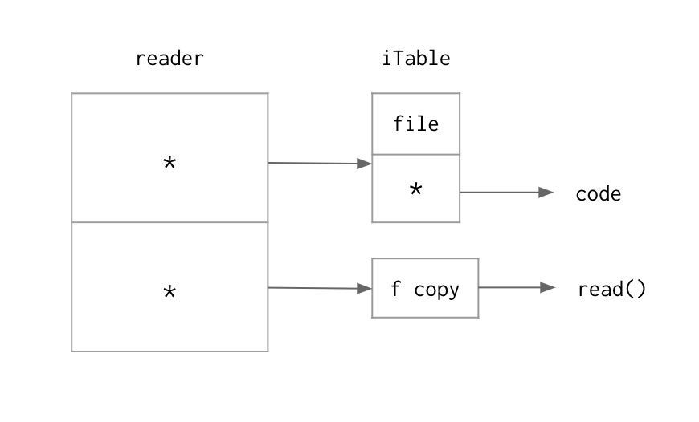

iTable for `file`

인터페이스를 통해서 `read`를 호출하면, `iTable`을 확인해서 이 타입에 맞는 `read` 함수를 찾고 이를 호출한다. 결과적으로 구체적 타입의 `read` 메서드를 호출하는 것이다.

```go
retrieve(f)
```

`p`도 이와 동일하다. `reader` 인터페이스의 첫 번째 워드는 `pipe` 타입을 가리키고, 두번째 워드는 `p`의 복사본을 가리킨다.

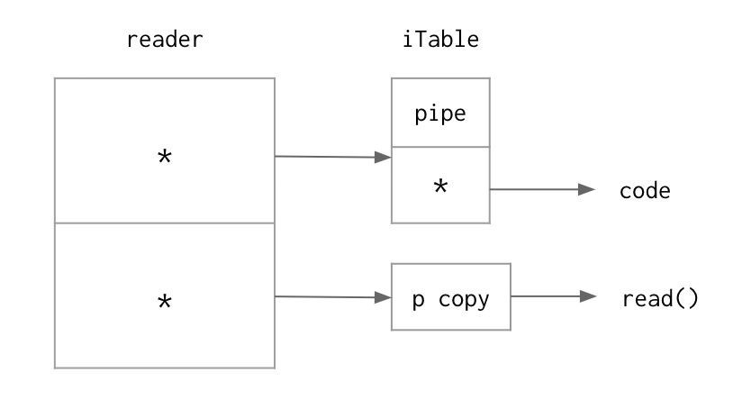

iTable for `pipe`

데이터가 변경되었기 때문에, 동작도 다르다.

```go
retrieve(p)
```

앞으로 `iTable`와 이를 가리키는 포인터를 간략하게 `*pipe`처럼 나타낼 것이다.

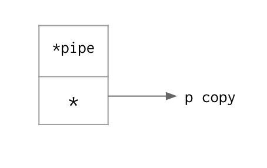

simple representation

**다형성 함수**

`retrieve`는 어떤 장치든 다 읽을 수 있고, 어떤 데이터든지 다 처리할 수 있다. 이러한 함수를 다형성 함수라 한다. 이 예제에서 사용된 파라미터는 `reader` 타입이다. 하지만 이는 인터페이스이므로 값이 없는 타입니다. 즉, 이 함수는 `reader` 인터페이스의 계약을 구현한 모든 타입을 다 파라미터로 받을 수 있다. 이 함수는 구체적 타입에 대해서는 전혀 알지 못하므로, 이는 완전히 디커플링 되어 있다. 이는 Go에서 할 수 있는 최상위의 디커플링이다. 이러한 구현 방법은 간결하고 효율적이다. 이 방법을 사용하기 위해 필요한 것은 오직 인터페이스를 통한 구체적 타입 데이터로의 간접적 접근뿐이다.[재방문]

```go
func retrieve(r reader) error {
    data := make([]byte, 100)

    len, err := r.read(data)
    if err != nil {
        return err
    }

    fmt.Println(string(data[:len]))
    return nil
}
```

```
<rss><channel><title>Going Go Programming</title></channel></rss>
{name: "hoanh", title: "developer"}
```

### 포인터 리시버를 이용한 인터페이스

`notifier`는 인터페이스로 알림을 보내는 타입들의 동작을 정의한다.

```go
type notifier interface {
    notify()
}
```

`printer` 역시 인터페이스로, 어떤 정보를 출력하는 동작을 정의한다.

```go
type printer interface {
    print()
}
```

`user`는 프로그램 내의 사용자 정보를 담을 타입을 정의한다.

```go
type user struct {
    name  string
    email string
}
```

`print`는 `user` 타입의 name과 email 정보를 출력한다.

```go
func (u user) print() {
    fmt.Printf("My name is %s and my email is %s\n", u.name, u.email)
}
```

`notify`는 포인터 리시버를 사용해서 `notifier` 인터페이스를 구현한다.

```go
func (u *user) notify() {
    fmt.Printf("Sending User Email To %s<%s>\n", u.name, u.email)
}
```

`String`은 `fmt.Stringer` 인터페이스를 구현한다. `fmt`는 지금까지 화면에 정보를 출력하기 위해서 사용한 패키지로, `String`을 구현하는 데이터가 주어지면 기존 동작이 아닌 새롭게 구현된 동작을 수행한다. 참조에 의한 호출을 사용하기 때문에, 포인터만이 이 인터페이스를 만족한다.

```go
func (u *user) String() string {
    return fmt.Sprintf("My name is %q and my email is %q", u.name, u.email)
}
```

`user` 타입의 데이터를 만들어보자.

```go
u := user{"Hoanh", "hoanhan@email.com"}
```

참조에 의한 호출로 `u`를 전달하는 다형성 함수를 호출하자: `sendNotification(u)`. 하지만 컴파일러는 이 호출을 허락하지 않고 다음의 에러 메시지를 보여준다: “cannot use u (type user) as type notifier in argument to sendNotification: user does not implement notifier (notify method has pointer receiver)” 이는 무결성을 위반해서 발생한 문제이다.

**메서드 집합**

메서드 집합의 개념과 관련하여 몇 가지 규칙이 존재한다. 앞서 발생한 에러는 이 규칙을 위반한 것이다.

다음은 그 규칙들이다.

- 주어진 타입 T의 어떤 값에 대해, 값 리시버로 구현한 메서드들만이 이 타입의 메서드 집합에 속한다.
- 주어진 타입 *T (타입 T의 포인터)의 어떤 값에 대해, 값 리시버와 포인터 리시버를 사용하는 모든 메서드들이 이 타입의 메서드 집합에 속한다.

즉, 어떤 타입의 포인터를 사용한다면 선언된 모든 메서드들은 모두 이 포인터를 통해 사용이 가능하다. 만약 어떤 타입의 값을 사용한다면 값에 의한 호출을 사용하는 메서드들만이 사용이 가능하다.

앞서 메서드를 공부할 때, 둘 중 어떤 호출을 사용하든 이러한 문제가 발생하지 않았다. 이는 메서드를 구체적 타입의 값을 통해 호출하였기 때문에 Go가 내부적으로 정상 동작이 가능하게끔 하였다. 하지만 여기서는 인터페이스에 구체적 타입의 값을 저장하고 이 인터페이스를 통해서 메서드를 호출하려고 하였다. 하지만 해당 메서드가 포인터 리시버를 사용하기 때문에 계약을 만족시키지 못하는 것이다.

왜 포인터 리시버로는 값을 통해 호출되는 메서드 집합을 사용할 수 없을까? 타입 T의 값에 대해 참조에 의한 호출을 허락하지 않는 무결성 문제란 무엇인가?

인터페이스를 만족하는 모든 값이 주소를 가진다고 100% 보장할 수 없다. 만약 어떤 값이 주소를 가지고 있지 않다면, 이는 공유할 수 없으므로 포인터 리시버를 사용할 수 없다. 다음의 예를 살펴보자.

`int`와 동일한 `duration`이라는 타입을 선언하자.

```go
type duration int
```

포인터 리시버를 사용해서 `duration`에 `notify` 메서드를 정의하자. 이제 이 타입은 포인터 리시버를 통해 `notifier` 인터페이스를 구현한 것이다.

```go
func (d *duration) notify() {
    fmt.Println("Sending Notification in", *d)
}
```

`42`를 받아서, 이를 `duration` 타입으로 변경 후 `notify` 메서드를 호출해보자. 이때, 컴파일러는 다음과 같은 에러 메시지를 보여준다.

- “cannot call pointer method on duration(42)”
- “cannot take the address of duration(42)”

```go
duration(42).notify()
```

주소 값을 얻을 수 없는 이유는 `42`가 변수에 저장된 값이 아니기 때문이다. 이는 여전히 리터럴 값으로 타입을 알 수 없다. 하지만 `duration`은 여전히 `notifier` 인터페이스를 구현한다.

다시 본 예제로 돌아와서, 이러한 에러가 발생했다는 것은 값에 의한 호출과 참조에 의한 호출이 혼용되었음을 알 수 있다. `u`는 포인터 리시버를 통해서 `notifier` 인터페이스를 구현하였지만, `u`의 복사본을 통해 해당 메서드를 호출하려고 한 것이다. 이는 일관적이지 못하다.

**교훈**

포인터 리시버를 이용해서 인터페이스를 구현한다면, 반드시 참조에 의한 호출을 사용해야 한다. 만약 값 리시버를 사용해서 인터페이스를 구현한다면, 값에 의한 호출과 참조에 의한 호출 모두를 사용할 수 있다. 하지만, 일관성을 유지하기 위해서 이 경우에도 값에 의한 호출을 사용하는 것을 권장한다. 다만 Unmarshal과 같은 함수를 위해서는 참조에 의한 호출을 사용해야만 할 수도 있다.

이 문제를 해결하기 위해서는, `u` 대신 `u`의 주소 값(&u)를 전달해야 한다. `user`의 값을 만들고 이 값의 주소 값을 전달하면, 인터페이스는 `user` 타입의 주소 값을 가지게 되고 원본 값을 가리킬 수 있게 된다.

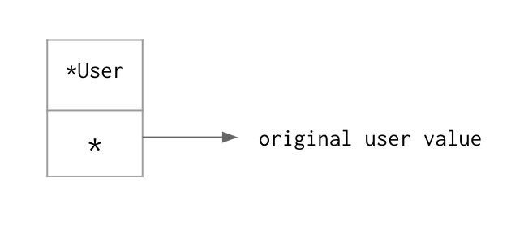

pointer of `u`

```go
sendNotification(&u)
```

`sendNotification`은 다형성 함수이다. 이 함수는 `notifier` 인터페이스를 구현하는 타입의 값을 받아 알림을 보낸다. 이 함수는 다음과 같이 말하는 것이다: 나는 `notifier` 인터페이스를 구현하는 타입의 값 또는 포인터를 받을 것이다. 그리고 나는 인터페이스를 통해서 동작을 호출할 것이다.

```go
func sendNotification(n notifier) {
    n.notify()
}
```

이와 유사하게, `u`의 값을 `Println`에게 전달하면, 기존 형태의 출력을 보게 된다. 하지만 만약 `u`의 주소 값을 전달하면, 앞서 정의한 `String`으로 기존 동작을 덮어써서 새로운 형태의 출력을 사용하게 된다.

```go
fmt.Println(u)
fmt.Println(&u)
```

```
Sending User Email To Hoanh<hoanhan@email.com>
{Hoanh hoanhan@email.com}
My name is "Hoanh" and my email is "hoanhan@email.com"
```

### 인터페이스 타입의 슬라이스

인터페이스를 저장할 수 있는 슬라이스를 만들자. 이 슬라이스에는 `printer` 인터페이스를 구현하는 모든 타입의 값이나 포인터를 저장할 수 있다.

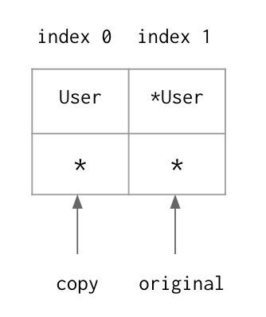

value and pointer

```go
entities := []printer{
```

이 슬라이스에 값을 저장하면, 인터페이스의 값은 복사본을 가지게 된다. 따라서 원본 데이터에 변경이 발생하더라도, 이를 확인할 수는 없다.

```go
    u,
```

슬라이스에 포인터를 저장하면, 인터페이스의 값은 원본 데이터를 가리키는 주소 값을 복사하고 이를 가지게 된다. 따라서 원본 데이터의 변경을 확인할 수 있다.

```go
    &u,
}
```

`u`의 `name`과 `email`을 변경해보자.

```go
u.name = "Hoanh An"
u.email = "hoanhan101@gmail.com"
```

슬라이스를 순회하면서 복사된 인터페이스의 값을 통해 `print`를 호출해보자.

```go
for _, e := range entities {
    e.print()
}
```

```
My name is Hoanh and my email is hoanhan@email.com
My name is Hoanh An and my email is hoanhan101@gmail.com
```